Toronto Bicycle Theft Dataset: [Toronto Police Services](http://data.torontopolice.on.ca/datasets/bicycle-thefts)

Toronto Spatial Dataset: [Toronto Open Data](https://open.toronto.ca/dataset/neighbourhoods/)

# 背景

多伦多市共有140个社区，如下图1所示。多伦多是一个大城市，许多人骑着自行车从不同的社区上下班。

[figure not shown]

Figure 1 City of Toronto neighbourhoods (Toronto Government, 2021)

但是，多伦多市区每年都有很多自行车被盗,《加拿大全球新闻》已经在犯罪渠道中报道了这种现象———— *到2020年，将有近4,000辆自行车被盗，其中公寓公寓和出租房内或旁边的盗窃数量正在增加。2020年的总数大约是2014年的三倍。*

本次分析希望通过研究识别多伦多附近地区不同程度的盗窃风险，并且挖掘盗窃案特征可以帮助政府或个人保护自己的自行车，这也有利于可持续交通发展。

# 研究问题

1. 是否可以对2014年至2020年多伦多市这些自行车失窃案的特征进行分类或描述？
2. 是否有可能从这些聚类模式中学习以优化城市自行车基础设施规划？

# 数据探索性分析

## 4.1 Data Input

In this section, the theft bicycle dataset is transformed into pandas DataFrame. The time of loading data is calculated as given below.

```python
# read Geojson file
import numpy as np
import pandas as pd
import geopandas as gpd
import datetime as dt
import time
# WORK_PATH = "/Users/fangzeqiang/Desktop/SDSV-T2/CASA0006-DSSS/Assessment/"

import ssl
ssl._create_default_https_context = ssl._create_unverified_context
# supported by StackOverflow https://stackoverflow.com/questions/27835619/urllib-and-ssl-certificate-verify-failed-error

# read the data
# This reading operation might take 25s because the size of it is 25MB
t0 = time.time()
url = "https://raw.githubusercontent.com/fang-zeqiang/CASA0006_DSSS/main/Dataset/Bicycle_Thefts.geojson"
print('Loading data from ', url)
df = gpd.read_file(url)
print('time taken', time.time()-t0, 'second')
# df.info()
df.head()
```

```
Loading data from  https://raw.githubusercontent.com/fang-zeqiang/CASA0006_DSSS/main/Dataset/Bicycle_Thefts.geojson
time taken 36.110806941986084 second
```

|  | OBJECTID | event_unique_id | Primary_Offence | Occurrence_Date | Occurrence_Year | Occurrence_Month | Occurrence_DayOfWeek | Occurrence_DayOfMonth | Occurrence_DayOfYear | Occurrence_Hour | ... | Bike_Model | Bike_Type | Bike_Speed | Bike_Colour | Cost_of_Bike | Status | Longitude | Latitude | ObjectId2 | geometry |
| --- | --- | --- | --- | --- | --- | --- | --- | --- | --- | --- | --- | --- | --- | --- | --- | --- | --- | --- | --- | --- | --- |
| 0 | 17744 | GO-20179016397 | THEFT UNDER | 2017-10-03T04:00:00+00:00 | 2017 | October | Tuesday | 3 | 276 | 14 | ... | ESCAPE 2 | OT | 7 | BLK | 700.0 | STOLEN | -79.506560 | 43.648427 | 1 | POINT (-79.50656 43.64843) |
| 1 | 17759 | GO-20172033056 | THEFT UNDER - BICYCLE | 2017-11-08T05:00:00+00:00 | 2017 | November | Wednesday | 8 | 312 | 3 | ... | None | TO | 1 | BLK | 1100.0 | RECOVERED | -79.504849 | 43.654623 | 2 | POINT (-79.50485 43.65462) |
| 2 | 17906 | GO-20189030822 | THEFT UNDER - BICYCLE | 2018-09-14T04:00:00+00:00 | 2018 | September | Friday | 14 | 257 | 9 | ... | CROSSTRAIL | MT | 24 | BLK | 904.0 | STOLEN | -79.511709 | 43.648253 | 3 | POINT (-79.51171 43.64825) |
| 3 | 17962 | GO-2015804467 | THEFT UNDER | 2015-05-07T04:00:00+00:00 | 2015 | May | Thursday | 7 | 127 | 18 | ... | None | TO | 10 | BLKDGR | 400.0 | STOLEN | -79.511709 | 43.648253 | 4 | POINT (-79.51171 43.64825) |
| 4 | 17963 | GO-20159002781 | THEFT UNDER | 2015-05-16T04:00:00+00:00 | 2015 | May | Saturday | 16 | 136 | 12 | ... | None | MT | 6 | RED | 600.0 | STOLEN | -79.511327 | 43.647364 | 5 | POINT (-79.51133 43.64736) |

5 rows × 34 columns

## 4.2 Data Pre-processing

For find valuable information, the target attributes are selected. Then the data cleaning process is given to this filtered DataFrame, which can help to find the missing value precentage in the dataset. Under this circumstance, it can be descided which columns need to be dropped or remain. In this bicycle theft dataset, the `Cost_of_Bike` remains because of its further value in finding potential relationship behind the dataset. It should be noticed that the `Hood_ID` contains noise value e.g. 'NSA' and should be cleaned and transformed into integer format before continuing the further data processing such as merging with geo-dataset

```python
# Pick the orriented varribles before exploration data analysis
df = df[['event_unique_id', 'Primary_Offence', 'Occurrence_Date',
       'Occurrence_Year', 'Occurrence_Month', 'Occurrence_DayOfWeek',
       'Occurrence_DayOfMonth', 'Occurrence_DayOfYear', 'Occurrence_Hour',
       'Division', 'City', 'Hood_ID', 'NeighbourhoodName', 'Location_Type',
       'Premises_Type', 'Bike_Make', 'Bike_Model', 'Bike_Type', 'Bike_Speed',
       'Bike_Colour', 'Cost_of_Bike', 'Status','Longitude', 'Latitude']]

# Data cleaning
total = df.isnull().sum().sort_values(ascending=False)
percent = (df.isnull().sum()/df.isnull().count()).sort_values(ascending=False)
missing_data = pd.concat([total, percent], axis=1, keys=['Total', 'Percent'])
print(missing_data)

# Drop the rows which have null value
df = df.dropna()

# drop the 'NSA' value
# Transform the Hood_ID's value into int32 value
df = df.drop(df[df.Hood_ID == 'NSA'].index)
df.Hood_ID.astype('int32').dtypes
```

```
                       Total   Percent
Bike_Model              9620  0.376237
Bike_Colour             2061  0.080605
Cost_of_Bike            1744  0.068208
Latitude                   0  0.000000
Division                   0  0.000000
Primary_Offence            0  0.000000
Occurrence_Date            0  0.000000
Occurrence_Year            0  0.000000
Occurrence_Month           0  0.000000
Occurrence_DayOfWeek       0  0.000000
Occurrence_DayOfMonth      0  0.000000
Occurrence_DayOfYear       0  0.000000
Occurrence_Hour            0  0.000000
Hood_ID                    0  0.000000
City                       0  0.000000
Longitude                  0  0.000000
NeighbourhoodName          0  0.000000
Location_Type              0  0.000000
Premises_Type              0  0.000000
Bike_Make                  0  0.000000
Bike_Type                  0  0.000000
Bike_Speed                 0  0.000000
Status                     0  0.000000
event_unique_id            0  0.000000
```

```
dtype('int32')
```

To inspect all the numeric attributes in the dataset, the descriptive statistics are executed as given coding process below. Some findings from this processing:

```python
# check the numeric columns and descriptive statistics
import numpy as np
print(df.describe(include = [np.number]))
```

```
       Occurrence_Year  Occurrence_DayOfMonth  Occurrence_DayOfYear  \
count     14530.000000           14530.000000          14530.000000
mean       2017.139023              15.635237            200.980592
std           1.960326               8.555314             77.026686
min        2010.000000               1.000000              1.000000
25%        2016.000000               8.000000            151.000000
50%        2017.000000              16.000000            203.000000
75%        2019.000000              23.000000            257.000000
max        2020.000000              31.000000            366.000000

       Occurrence_Hour    Bike_Speed  Cost_of_Bike     Longitude      Latitude
count     14530.000000  14530.000000  14530.000000  14530.000000  14530.000000
mean         13.385891     15.132209   1067.966758    -79.395992     43.670924
std           6.440467     10.061826   1557.083388      0.053836      0.035947
min           0.000000      0.000000      0.000000    -79.620643     43.587350
25%           9.000000      7.000000    464.250000    -79.417302     43.649254
50%          14.000000     18.000000    700.000000    -79.392273     43.661302
75%          19.000000     21.000000   1200.000000    -79.375924     43.678022
max          23.000000     99.000000  88496.000000    -79.124373     43.832703
```

## 4.3 Data Preparation

```python
# Read the Boundaries of City of Toronto Neighbourhoods.
import time

# This process may take 3 seconds,
t1 = time.time()
url_geo = "https://raw.githubusercontent.com/fang-zeqiang/CASA0006_DSSS/main/Dataset/Neighbourhoods.geojson"
print('Loading data from ', url)
gdf = gpd.read_file(url_geo)
print('time taken', time.time()-t1, 'second')

gdf.plot()
```

```
Loading data from  https://raw.githubusercontent.com/fang-zeqiang/CASA0006_DSSS/main/Dataset/Bicycle_Thefts.geojson
time taken 5.7711570262908936 second
```

There is a varriable called `AREA_SHORT_CODE` which is the same as `Hood_ID` in the bicycle dataframe. As discussing in the Introduction section, bicycle theft data will be explored in neighbourhoods of Toronto. This is the key of merging these two dataset.

```python
gdf.columns
```

```
Index(['_id', 'AREA_ID', 'AREA_ATTR_ID', 'PARENT_AREA_ID', 'AREA_SHORT_CODE',
       'AREA_LONG_CODE', 'AREA_NAME', 'AREA_DESC', 'X', 'Y', 'LONGITUDE',
       'LATITUDE', 'OBJECTID', 'Shape__Area', 'Shape__Length',
       'CLASSIFICATION', 'CLASSIFICATION_CODE', 'geometry'],
      dtype='object')
```

```python
# dfc means df copy version
dfc = df.copy()
dfc.Hood_ID.astype('int32')
print(gdf.AREA_SHORT_CODE.unique())
print(dfc.Hood_ID.unique())
# we can see the different types between these two DataFrame
```

```
[ 96  95 109  64 103 130  53  26   6 124  46 116  83  30  21  98 100 121
  74 134  87  47 104  35   1 136  43  40  70  85 139  57 140  65   2  76
  34  42 117  81  91  25 113  11  32  41 111  59   5 138 119  20 128  84
  61 106 129  90 115   9  28  69 102  48   8  66  36  24  79  31  78  58
  23  45  80  18 112  82  39  52 137  86  54   7  60 122 127  72  44 110
  73 135  17 105  33  92  12  29 132  19 114  13  49  89  93 123 120  75
  68  62  15  77  50 108  71  14 131 125  67 107  88  99   4  55   3  63
 118  16 101  10  38  27  56  94  97 126 133  22  37  51]
['15' '16' '14' '17' '1' '2' '7' '8' '11' '3' '4' '5' '6' '12' '13' '9'
 '10' '25' '26' '27' '28' '29' '30' '31' '18' '19' '20' '21' '22' '23'
 '24' '40' '41' '45' '42' '37' '39' '43' '36' '44' '32' '34' '35' '38'
 '46' '47' '48' '33' '57' '58' '59' '51' '56' '52' '53' '54' '55' '49'
 '50' '63' '64' '65' '60' '61' '62' '70' '67' '69' '66' '68' '71' '72'
 '73' '74' '75' '76' '77' '78' '79' '81' '80' '82' '85' '83' '84' '88'
 '86' '87' '89' '93' '90' '92' '91' '94' '95' '96' '98' '99' '97' '100'
 '102' '103' '106' '104' '101' '105' '119' '120' '121' '122' '107' '124'
 '111' '108' '112' '113' '114' '117' '118' '109' '115' '116' '123' '110'
 '125' '126' '127' '138' '139' '140' '136' '135' '128' '129' '130' '137'
 '132' '133' '134' '131']
```

Before merging by neighbourhoods, this studying focus more on these three numeric variables in below table. And these attributes will be calculated by the below cod. The descriptive statistics presented below can help us understand how to scale these three value. For example, lower than 955(median) cost of bike might represent that the bike is cheap while higher than 1194(75% quantile)one might mean that the bike is expensive.

| Variables | Definition |
| --- | --- |
| `Cost_of_Bike` | Cost of Bike |
| `Bike_Speed` | Speed of Bike |
| `Frequency of Theft Bike` | Frequency of bike theft happening in a specific neighbourbood |

```python
# Group by Hood_ID and return the mean of Cost_of_Bike in the group.
a = pd.DataFrame(dfc.groupby('Hood_ID')['Cost_of_Bike'].mean())
b = pd.DataFrame(dfc.groupby('Hood_ID')['Bike_Speed'].mean())
c = pd.DataFrame(dfc.groupby('Hood_ID')['event_unique_id'].count())
# change the columns' name
c.rename(columns={'event_unique_id':'Freq'},inplace=True)

# Then we should merge these three attributes' values
temp_1 = a.join(b)
temp_2 = temp_1.join(c)
dfm = temp_2.copy()
dfm.describe()
```

|  | Cost_of_Bike | Bike_Speed | Freq |
| --- | --- | --- | --- |
| count | 140.000000 | 140.000000 | 140.000000 |
| mean | 1011.725985 | 14.914925 | 103.785714 |
| std | 404.624440 | 2.860085 | 212.819300 |
| min | 338.250000 | 5.200000 | 2.000000 |
| 25% | 798.768772 | 13.419192 | 14.000000 |
| 50% | 955.953698 | 15.095490 | 31.500000 |
| 75% | 1194.012791 | 16.616099 | 87.250000 |
| max | 3084.043478 | 21.760000 | 1614.000000 |

```python
# it is of importance to transform your value into int32 type before merging
dfm['AREA_SHORT_CODE'] = dfm.index.astype('int32')
dfm.head()
```

| Hood_ID | Cost_of_Bike | Bike_Speed | Freq | AREA_SHORT_CODE |
| --- | --- | --- | --- | --- |
| 1 | 750.851852 | 16.481481 | 27 | 1 |
| 10 | 1258.307692 | 13.538462 | 13 | 10 |
| 100 | 1097.687500 | 19.468750 | 96 | 100 |
| 101 | 1017.619048 | 17.317460 | 63 | 101 |
| 102 | 1495.602941 | 15.955882 | 68 | 102 |

```python
dfm.corr()
```

|  | Cost_of_Bike | Bike_Speed | Freq | AREA_SHORT_CODE |
| --- | --- | --- | --- | --- |
| Cost_of_Bike | 1.000000 | 0.017208 | 0.068271 | -0.039500 |
| Bike_Speed | 0.017208 | 1.000000 | 0.037316 | -0.092421 |
| Freq | 0.068271 | 0.037316 | 1.000000 | 0.058694 |
| AREA_SHORT_CODE | -0.039500 | -0.092421 | 0.058694 | 1.000000 |

Then inspecting the merged dataframe(three variables), we can find there is less likely to find relationship among these attributes according to above correlation index. Also, it is obvious to see the distribution in this merged DataFrame `dfm` by introducing the `seaborn` exploratory data analysis method.

## 4.4 Descriptive Statistics

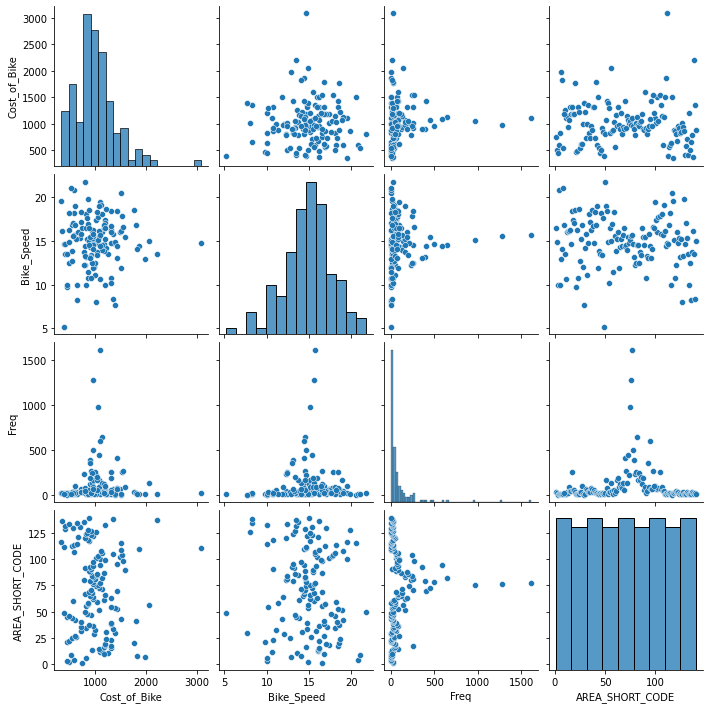

```python
import seaborn as sns
sns.pairplot(dfm)
```

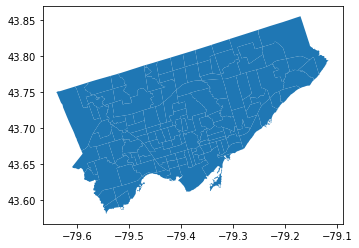

```python
# merge with original case
# dfmg = dfm with geo info
dfmg = pd.merge(gdf,dfm,left_on='AREA_SHORT_CODE',right_on='AREA_SHORT_CODE',how='inner').reset_index()
dfmg.plot()
```

The above map is complete after two DataFrames are merged which can indicate that there is no data missing in this merging process. In the next step, the analysis of maximum and minimum value analysis is given below to some insights before preparing the clustering analysis.

```python
# We can inspect the min and max in these three value in toronto
# ppd.head(5)
print('Frequency of Theft Cases')
print(dfmg[dfmg.Freq.isin([dfmg.Freq.max(), dfmg.Freq.min()])][['index','AREA_SHORT_CODE','AREA_NAME','Freq']])
print('\n'+'Cost of Theft Bikes')
print(dfmg[dfmg.Cost_of_Bike.isin([dfmg.Cost_of_Bike.max(), dfmg.Cost_of_Bike.min()])][['index','AREA_SHORT_CODE','AREA_NAME','Cost_of_Bike']])
print('\n'+'Speed of Theft Bikes')
print(dfmg[dfmg.Bike_Speed.isin([dfmg.Bike_Speed.max(), dfmg.Bike_Speed.min()])][['index','AREA_SHORT_CODE','AREA_NAME','Bike_Speed']])
```

```
Frequency of Theft Cases
     index  AREA_SHORT_CODE                               AREA_NAME  Freq
11      11              116                           Steeles (116)     2
111    111               77  Waterfront Communities-The Island (77)  1614
124    124                3        Thistletown-Beaumond Heights (3)     2

Cost of Theft Bikes
    index  AREA_SHORT_CODE                AREA_NAME  Cost_of_Bike
38     38              117         L'Amoreaux (117)    338.250000
46     46              111  Rockcliffe-Smythe (111)   3084.043478

Speed of Theft Bikes
     index  AREA_SHORT_CODE                   AREA_NAME  Bike_Speed
102    102               49  Bayview Woods-Steeles (49)        5.20
112    112               50       Newtonbrook East (50)       21.76
```

## 最大最小值分析

The key findings from this merged spatial and numeric dataset:

[figure not shown]

Figure 2 Highlighted neighbourhoods in the city of Toronto

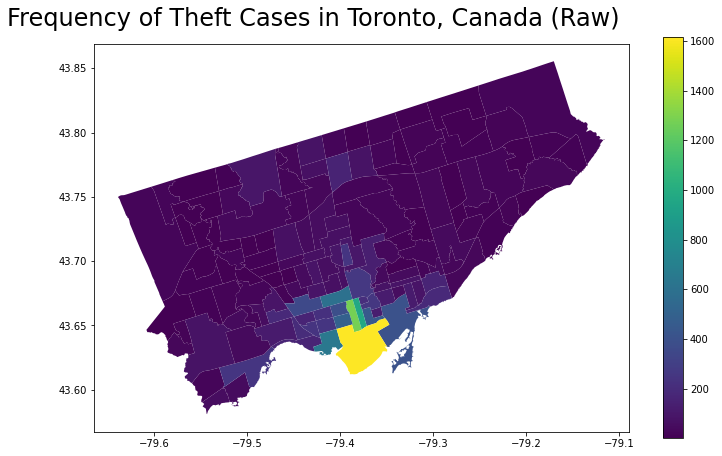

```python
import pysal as ps
import numpy as np
import pandas as pd
import seaborn as sns
import geopandas as gpd
import matplotlib.pyplot as plt

tfont = {'fontname':'DejaVu Sans', 'horizontalalignment':'left'}
f = plt.figure()
f.set_size_inches(12,7)

ax1 = f.add_subplot()
dfmg.plot(column='Freq', legend=True, cmap='viridis', figsize=(12,6), ax=ax1)

f.subplots_adjust(top=0.92)
f.suptitle(f"Frequency of Theft Cases in Toronto, Canada (Raw)", x=0.025, size=24, **tfont);
plt.savefig('Frequency_of_Theft_Cases.png', dpi=300)
```

The above distribution of frequency shows that the closer to the city center, the more frequently theft of bicycles occurs even though there are some exceptions

从这个地区分布图可以看到，自行车盗窃频率在市中心区域较高，市郊较低，呈渐变型分布

# 聚类分析

这里用k-means聚类分析

## 标准化

| Variables | Definition | Value Scale |
| --- | --- | --- |
| `Cost_of_Bike` | Cost of Bike | (338.25, 3084.04) |
| `Bike_Speed` | Speed of Bike | (5.2, 21.7) |
| `Frequency of Theft Bike` | Frequency of bike theft happening in a specific neighbourbood | (2, 1614) |

```python
from sklearn.preprocessing import RobustScaler, MinMaxScaler
rs = RobustScaler(quantile_range=(10.0, 90.0))

to_cluster = dfmg[['AREA_SHORT_CODE','Cost_of_Bike','Bike_Speed','Freq']].set_index('AREA_SHORT_CODE').copy()
to_cluster.head()

# normnise the value
normed = to_cluster.copy()
for c in to_cluster.columns.values:
    normed[c] = rs.fit_transform(to_cluster[c].values.reshape(-1,1))
normed.head()
```

| AREA_SHORT_CODE | Cost_of_Bike | Bike_Speed | Freq |
| --- | --- | --- | --- |
| 96 | 0.498111 | -0.265504 | 0.153500 |
| 95 | 0.137279 | -0.087086 | 2.306590 |
| 109 | 0.571615 | 0.137457 | -0.100287 |
| 64 | 0.009200 | -0.421695 | 0.218993 |
| 103 | 0.101972 | 0.346070 | 0.161686 |

## 找出最优聚类类簇数量

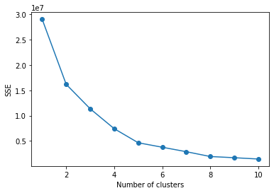

```python
# calculate SSE for a range of number of cluster
list_SSE = []
min_k = 1
max_k = 10
range_k = range(min_k, max_k+1)
for i in range_k:
    km = KMeans(
        n_clusters=i, init='random',
        n_init=10, max_iter=300,
        tol=1e-04, random_state=0
    )
    km.fit(to_cluster)
    # inertia is a concept in physics. Roughly it means SSE of clustering.
    list_SSE.append(km.inertia_)

# plot
plt.plot(range_k, list_SSE, marker='o')
plt.xlabel('Number of clusters')
plt.ylabel('SSE')
plt.show()
```

[output not shown]

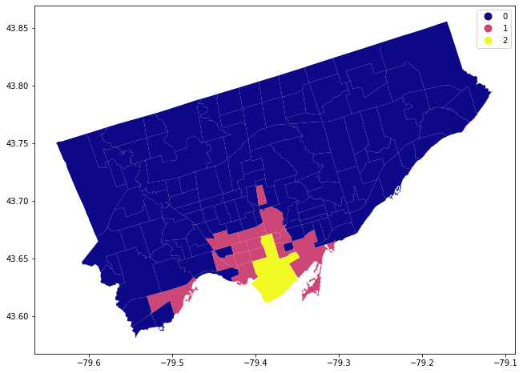

```python
# re-run the k-means process
from sklearn.cluster import KMeans
k_cluster = 3
random_seed = 1
kmeans_method = KMeans(n_clusters=k_cluster,random_state=random_seed)
kmeans_method.fit(normed)

dfmg['Kmeans_Cluster'] = kmeans_method.labels_
fig_kmeans_4 = dfmg.plot(column='Kmeans_Cluster', categorical=True, legend=True, figsize=(12,8),cmap = 'plasma');
from sklearn import metrics
print("Silhouette Score is :")
print(metrics.silhouette_score(normed, dfmg['Kmeans_Cluster']))
```

```python
kmeans_label = pd.DataFrame(kmeans_method.labels_, columns = ['kmeans_label'])

# to_cluster_labeled = pd.concat([to_cluster, DB_label], axis = 1).dropna()

temp = to_cluster.join(kmeans_label)
to_cluster_labeled = temp.copy()
to_cluster_labeled.head()

summary_df_kmeans = \
    to_cluster_labeled[['Cost_of_Bike','Bike_Speed','Freq','kmeans_label']].groupby('kmeans_label')\
    .mean() \
    .round()

summary_df_kmeans['count'] = to_cluster_labeled.kmeans_label.value_counts()
summary_df_kmeans
# summary_df.drop()
```

| kmeans_label | Cost_of_Bike | Bike_Speed | Freq | count |
| --- | --- | --- | --- | --- |
| 0.0 | 991.0 | 15.0 | 93.0 | 120 |
| 1.0 | 1088.0 | 15.0 | 201.0 | 16 |
| 2.0 | 1466.0 | 16.0 | 34.0 | 3 |

以上是各个类簇的中心点，代表了各个类簇的特点，具体的分析如下

如k均值聚类图（k = 3）所示，k-均值聚类分析还生成了3个聚类。 三个集群中包含的社区根据距市中心的距离分层分布。 例如，蓝色（群集0）中的社区不靠近市中心，而群集2（黄色区域）包含多伦多市中心中的大多数社区。

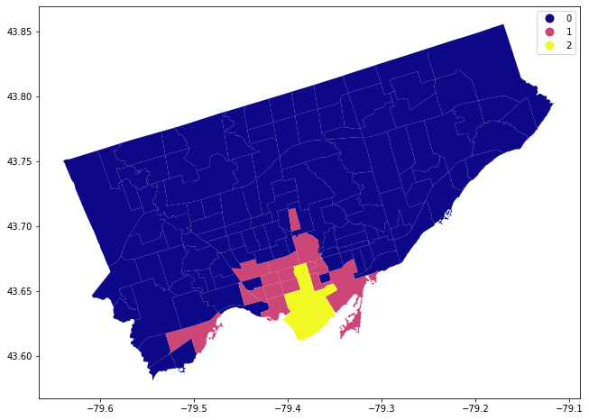

```python
fig_kmeans_4 = dfmg.plot(column='Kmeans_Cluster', categorical=True, legend=True, figsize=(12,8),cmap = 'plasma');
```

```python
summary_df_kmeans
```

| kmeans_label | Cost_of_Bike | Bike_Speed | Freq | count |
| --- | --- | --- | --- | --- |
| 0.0 | 991.0 | 15.0 | 93.0 | 120 |
| 1.0 | 1088.0 | 15.0 | 201.0 | 16 |
| 2.0 | 1466.0 | 16.0 | 34.0 | 3 |

# 结论

根据上面包含每个群集的字符信息的表，将`kmeans_label`转换为在业务领域中易于理解的其他单词非常重要。 为了更好地理解空间分布，以下表格还包括了地图上群集的颜色。

每个聚类都有其自身的特征，分析可以获得与多伦多邻域相对应的每个聚类的盗窃案件画像。这里在下表的“类别”列中以文本形式细化和描述每个群集的特征，这有助于政府在处理类似案件或采取有效政策时可以参考数据；

[output not shown]

1. 是否可以对2014年至2020年多伦多市这些自行车失窃案的特征进行分类或描述？

1. 是否有可能从这些聚类模式中学习以优化城市自行车基础设施规划？

政府应更加重视红色集群区自行车的盗窃案，并注意在这些地区建设自行车设施的投资计划。例如，停车位，储物柜和其他设施可用于保护自行车，如下图所示。对于黄色集群中的社区，建议在有限的空间内引入更多的自行车停放点，以尽可能多地保护更多和更昂贵的自行车，如下图第二图所示。

[figure not shown]

Figure 3 Bicyle Lockers in Toronto (City of Toronto, 2021)

[figure not shown]

Figure 4 Bicyle Station in Toronto (ibid, 2021)